# Bioestadística, Economía

Clase 12: Muestreo, Distribuciones Muestrales y Tamaño de Muestra

Departamento de Estadı́stica, Sede Bogotá

## Contenido

### Parte I: Tipos de muestreo

- Población, muestra y parámetro.
- Muestreo aleatorio simple.
- Muestreo sistemático.
- Muestreo estratificado y por conglomerados.

### Parte II: Inferencia muestral

- Distribuciones muestrales de $\bar{X}$ y $\hat{p}$.
- Error estándar y sesgo.
- Tamaño de muestra para media.
- Tamaño de muestra para proporción.

## Recorrido estadístico: de los datos a la inferencia

Clases 1–3

Estadística descriptiva

Tablas de frecuencia, medidas de centro y dispersión, gráficos exploratorios.

Clases 4–6

Probabilidad

Axiomas, probabilidad condicional, independencia, regla de Bayes.

Clases 7–9

Variables aleatorias

Discretas y continuas, FMP, FDP, FDA. Modelos: Binomial, Poisson, Normal.

Clase 10

Distribuciones

Exponencial, Gamma, Beta, Chi-cuadrado, $t$ de Student. Cálculo en R.

Clase 11

Momentos y TLC

$E(X)$, $\text{Var}(X)$, percentiles, Chebyshev. Teorema Central del Límite.

Clase 12 ← estamos aquí

Muestreo e inferencia

Tipos de muestreo, distribuciones muestrales, tamaño de muestra.

**Cada bloque es prerequisito del siguiente**: sin probabilidad no hay modelos, sin modelos no hay inferencia, sin muestreo no hay datos válidos.

## Muestreo en el análisis bioestadístico

El problema central

Todo el aparato probabilístico construido en las clases 4–11 describe **poblaciones**. En la práctica, la población completa es **inaccesible**: solo podemos observar una muestra.

La pregunta clave

¿Cómo seleccionar esa muestra para que los estadísticos $(\bar{x}, s^2, \hat{p})$ sean **estimadores confiables** de los parámetros $(\mu, \sigma^2, p)$? ¿Cuántas unidades necesito medir?

Posición en el flujo inferencial

✓ **Antes:** teoría de probabilidad y distribuciones

→ **Hoy:** diseño muestral y distribuciones muestrales

→ **Próximo:** intervalos de confianza y pruebas de hipótesis

La calidad de cualquier conclusión estadística está **limitada por la calidad del muestreo**. Un análisis sofisticado sobre una muestra mal diseñada produce inferencias inválidas.

## ¿Por qué muestrear?

- Estudiar toda la **población** (cada empresa, animal o sucursal) es costoso, tardado o destructivo.
- Una **muestra bien elegida** permite estimar parámetros con un margen de error controlable.
- Ejemplo: estimar la rentabilidad promedio de comercio en Huila sin medir los 200 000 empresas del municipio.
- El **muestreo probabilístico** garantiza que cada unidad tiene probabilidad conocida y positiva de ser seleccionada.
- Solo el muestreo probabilístico permite hacer inferencia estadística válida y calcular márgenes de error.
- La elección del método depende de la estructura de la población y los recursos disponibles.

## Conceptos clave

Población

Conjunto completo de unidades de interés. Descrita por **parámetros**: $\mu$, $\sigma^2$, $p$.

Muestra

Subconjunto de la población observado. Descrita por **estadísticos**: $\bar{x}$, $s^2$, $\hat{p}$.

Marco muestral

Lista completa de todas las unidades de la población de la que se extrae la muestra.

Los estadísticos $(\bar{x},\, s^2,\, \hat{p})$ son **estimadores** de los parámetros $(\mu,\, \sigma^2,\, p)$. Su distribución de probabilidad se llama **distribución muestral**.

## Muestreo con reemplazo y sin reemplazo

Con reemplazo (CR)

Cada unidad seleccionada **regresa al marco muestral** antes de la siguiente extracción. Puede ser elegida más de una vez.

- Probabilidad de selección constante: $\pi_i = 1/N$ en cada extracción.
- Las selecciones son **independientes** entre sí.
- Análisis más sencillo; base del *bootstrap* y simulación.
- Menos eficiente: repetir una unidad no agrega información nueva.

Sin reemplazo (SR)

Cada unidad puede ser seleccionada **como máximo una vez**. Al extraerla, no regresa al marco.

- Probabilidad de selección varía tras cada extracción.
- Las selecciones son **dependientes**; requiere factor de corrección $\sqrt{(N-n)/(N-1)}$ para el SE.
- **Estándar en encuestas y estudios de campo:** mayor eficiencia por observación.

Cuando $n/N \leq 0.05$, la diferencia práctica entre CR y SR es despreciable y el factor de corrección puede ignorarse.

## Muestreo probabilístico y no probabilístico

Probabilístico

Cada unidad de la población tiene una **probabilidad conocida y positiva** de ser seleccionada.

- Permite calcular **errores de estimación** e intervalos de confianza.
- Sustenta la inferencia estadística formal.
- Tipos: MAS, sistemático, estratificado, conglomerados.

Ejemplo: sortear 50 sucursales de 500 con `sample()` en R.

No probabilístico

Las unidades se seleccionan por **criterio subjetivo, accesibilidad o conveniencia**, sin probabilidades definidas.

- **Conveniencia:** lo más fácil de acceder.
- **Juicio / experto:** el investigador elige casos.
- **Bola de nieve:** cada caso refiere al siguiente.

No permite cuantificar el error ni generalizar a la población.

Tipos de Muestreo

Muestrear es seleccionar un subconjunto representativo de una población para inferir sus características sin observar todos sus elementos. Los tipos de muestreo definen la manera en que se selecciona una muestra de una población para obtener información representativa.

## Muestreo aleatorio simple

Definición

Se seleccionan $n$ unidades de una población de $N$ de modo que **cada posible muestra de tamaño $n$ tiene igual probabilidad** de ser elegida:
$$P(\text{muestra}) = \frac{1}{\binom{N}{n}}$$
Cada unidad tiene probabilidad de inclusión $\pi_i = n/N$.

#### Ventajas y limitaciones

- **Ventaja:** simple de analizar; base de la teoría estadística clásica.
- **Puede realizarse** con o sin reemplazo (sin reemplazo es más eficiente).
- **Limitación:** requiere marco muestral completo y actualizado.

Ejemplo en R

De 500 sucursales de servicios se eligen 50 de forma aleatoria: `sample(1:500, 50, replace = FALSE)`

## Inferencia bajo MAS

Estimador

Media: $\displaystyle\bar{x} = \frac{1}{n}\sum_{i=1}^n x_i \quad$ insesgado: $E(\bar{x})=\mu$

Proporción: $\displaystyle\hat{p} = \frac{\text{núm. de éxitos}}{n} \quad$ insesgado: $E(\hat{p})=p$

Varianza del estimador (SR)

$$\widehat{\text{Var}}(\bar{x}) = \frac{s^2}{n}\!\left(1-\frac{n}{N}\right) \quad \widehat{\text{Var}}(\hat{p}) = \frac{\hat{p}(1-\hat{p})}{n}\!\left(1-\frac{n}{N}\right)$$
El término $\left(1-\dfrac{n}{N}\right)$ es el **FPC** (factor de corrección finita). Se omite cuando $n/N \leq 0.05$.

Tamaño de muestra

Para $\mu$: $\displaystyle n = \frac{N z_{\alpha/2}^2 s^2}{N e^2 + z_{\alpha/2}^2 s^2}$

Para $p$: $\displaystyle n = \frac{N z_{\alpha/2}^2 \hat{p}(1-\hat{p})}{N e^2 + z_{\alpha/2}^2 \hat{p}(1-\hat{p})}$

Si $N\to\infty$ recuperan las fórmulas de la clase 11.

Intervalo de confianza

Para $\mu$: $\displaystyle\bar{x} \pm z_{\alpha/2}\sqrt{\frac{s^2}{n}\!\left(1-\frac{n}{N}\right)}$

Para $p$: $\displaystyle\hat{p} \pm z_{\alpha/2}\sqrt{\frac{\hat{p}(1-\hat{p})}{n}\!\left(1-\frac{n}{N}\right)}$

## Muestreo sistemático

Definición

Se calcula el intervalo de salto $k = \lfloor N/n \rfloor$ y se elige un arranque aleatorio $r \in \{1,\ldots,k\}$. La muestra es:
$$\{r,\; r+k,\; r+2k,\; \ldots,\; r+(n-1)k\}$$

#### Características

- **Ventaja:** fácil de ejecutar en campo; cobertura uniforme del espacio.
- **Riesgo:** sesgo si existe periodicidad en la población (ej. disposición cíclica de segmentos).
- Útil cuando la lista está ordenada o la población tiene estructura espacial definida.

Ejemplo económico

De 1 000 palmas en filas continuas, se toma cada décima empresa ($k=10$) a partir de un arranque elegido al azar.

## Inferencia bajo muestreo sistemático

Estimador

$\displaystyle\bar{x}_{sys} = \frac{1}{n}\sum_{j=0}^{n-1} x_{r+jk}$

Media de las $n$ unidades con arranque $r$ e intervalo $k$. Insesgado si $r$ se sortea en $\{1,\ldots,k\}$.

Varianza del estimador

$\displaystyle\widehat{\text{Var}}(\bar{x}_{sys}) \approx \frac{s^2}{n}\!\left(1-\frac{n}{N}\right)$

Válida si no hay **periodicidad** en la lista. Si hay ciclos (ej. surcos alternados), subestima el error real.

Tamaño de muestra

$n$ queda fijado por el intervalo de salto: $\displaystyle n = \left\lfloor \frac{N}{k} \right\rfloor$

Se elige $k$ de modo que el $n$ resultante cumpla la precisión deseada, usando la fórmula del MAS como referencia.

Intervalo de confianza

$\displaystyle\bar{x}_{sys} \pm z_{\alpha/2}\sqrt{\frac{s^2}{n}\!\left(1-\frac{n}{N}\right)}$

Aproximación válida si el arranque es aleatorio y la lista no tiene estructura periódica.

## Muestreo estratificado

Definición

La población ($N$ unidades) se divide en $H$ grupos mutuamente excluyentes llamados **estratos**, donde el estrato $h$ contiene $N_h$ unidades ($\sum_{h=1}^H N_h = N$). Se extrae una MAS dentro de cada estrato. Asignación proporcional:
$$n_h = n \cdot \frac{N_h}{N} \quad (h = 1, 2, \ldots, H)$$
Estimador de la media global:
$$\bar{x}_{st} = \sum_{h=1}^{H} \frac{N_h}{N}\,\bar{x}_h$$

#### Características

- **Ventaja:** mayor precisión al reducir la varianza entre estratos; permite comparar subpoblaciones.
- **Requisito:** los estratos deben ser mutuamente excluyentes y exhaustivos.

Ejemplo económico

Prevalencia de mosca blanca en empresas de Cundinamarca por altitud: baja (<1 000 m), media (1 000–2 000 m) y alta (>2 000 m). Muestreo proporcional en cada estrato.

## Inferencia bajo muestreo estratificado

Estimador

$\displaystyle\bar{x}_{st} = \sum_{h=1}^{H} W_h\,\bar{x}_h, \quad W_h = \frac{N_h}{N}$

Promedio ponderado de las medias por estrato. Proporción: $\displaystyle\hat{p}_{st} = \sum_{h=1}^{H} W_h\,\hat{p}_h$

Varianza del estimador

$\displaystyle\widehat{\text{Var}}(\bar{x}_{st}) = \sum_{h=1}^{H} W_h^2 \frac{s_h^2}{n_h}\!\left(1-\frac{n_h}{N_h}\right)$

$s_h^2$: varianza dentro del estrato $h$. Menor que la del MAS si los estratos son homogéneos.

Tamaño de muestra total

$\displaystyle n = \frac{z_{\alpha/2}^2 \sum_h N_h s_h^2 / N}{e^2 + z_{\alpha/2}^2 \sum_h N_h s_h^2 / N^2}$

Luego $n_h = n \cdot N_h/N$. Si $s_h^2 \approx s^2\ \forall h$, reduce a la fórmula del MAS.

Intervalo de confianza

$\displaystyle\bar{x}_{st} \pm z_{\alpha/2}\sqrt{\sum_{h=1}^H W_h^2 \frac{s_h^2}{n_h}\!\left(1-\frac{n_h}{N_h}\right)}$

Para $p$: $\displaystyle\hat{p}_{st} \pm z_{\alpha/2}\sqrt{\sum_{h=1}^H W_h^2 \frac{\hat{p}_h(1-\hat{p}_h)}{n_h}\!\left(1-\frac{n_h}{N_h}\right)}$

## Muestreo por conglomerados

Definición

Un **conglomerado** es un grupo natural y preexistente de unidades físicamente agrupadas en el campo: una vereda, un lote, una empresa, un galpón. Los conglomerados a visitar se sortean con **MAS** sobre la lista de grupos. Una vez seleccionado un conglomerado se procede en:

- **Una etapa:** se observan *todas* las unidades del conglomerado.
- **Dos etapas:** se aplica una segunda MAS dentro del conglomerado para elegir una submuestra.

#### Características

- **Ventaja:** no requiere listar cada unidad de toda la región; reduce costos de desplazamiento concentrando el trabajo en pocos sitios.
- **Limitación:** si todas las vacas de una misma empresa se parecen entre sí (conglomerado homogéneo), se pierde eficiencia estadística respecto al MAS.

Ejemplo económico

Producción de leche en Nariño: el conglomerado es la **vereda**. Se sortean 10 veredas al azar y se censan *todas* las vacas en esas veredas, en lugar de viajar a cada empresa del departamento.

## Inferencia bajo muestreo por conglomerados

Estimador

$\displaystyle\bar{x}_{cl} = \frac{1}{m}\sum_{i=1}^{m} \bar{x}_i$

$m$ conglomerados elegidos de $M$ totales; $\bar{x}_i$ es la media del grupo $i$. Insesgado si los grupos se sortean con MAS.

Varianza del estimador

$\displaystyle\widehat{\text{Var}}(\bar{x}_{cl}) = \frac{s_c^2}{m}\!\left(1-\frac{m}{M}\right)$

$s_c^2 = \frac{1}{m-1}\sum_{i=1}^m (\bar{x}_i - \bar{x}_{cl})^2$: varianza **entre** grupos. Aumenta si los grupos son internamente homogéneos.

Número de conglomerados

$\displaystyle m = \frac{M\,z_{\alpha/2}^2\,s_c^2}{M\,e^2 + z_{\alpha/2}^2\,s_c^2}$

$s_c^2$ se estima con un estudio piloto. $m$ es número de *grupos*, no de individuos.

Intervalo de confianza

$\displaystyle\bar{x}_{cl} \pm z_{\alpha/2}\sqrt{\frac{s_c^2}{m}\!\left(1-\frac{m}{M}\right)}$

## Comparación de métodos de muestreo

| Método | Estructura poblacional | Costo | Precisión relativa |
| --- | --- | --- | --- |
| Aleatorio simple | Cualquiera, marco completo | Medio | Referencia |
| Sistemático | Ordenada o espacial | Bajo | ≈ MAS sin periodicidad |
| Estratificado | Estratos definidos y distintos | Medio | Mayor que MAS |
| Conglomerados | Agrupada geográficamente | Bajo | Menor que MAS |

## Implementación en R: tipos de muestreo

```r
set.seed(42)
N <- 500   # empresas comerciales en Huila

# MAS sin reemplazo, n = 50
mas <- sample(1:N, 50, replace = FALSE)

# Sistemático: k = 10, arranque aleatorio
k <- 10; r <- sample(1:k, 1)
sist <- seq(r, N, by = k)

# Estratificado proporcional (altitud baja=250, media=180, alta=70)
Nh <- c(250, 180, 70); n <- 50
nh <- round(n * Nh / N)
id <- split(1:N, rep(c("baja","media","alta"), Nh))
estrat <- unlist(mapply(sample, id, nh))

cat("MAS:", length(mas), "| Sist:", length(sist),
    "| Estrat:", sum(nh), "\n")
```

```
MAS: 50 | Sist: 50 | Estrat: 50
```

```r
cat("n por estrato:", nh, "\n")
```

```
n por estrato: 25 18 7
```

Distribuciones Muestrales

La distribución muestral de un estadístico describe su comportamiento probabilístico al repetir el muestreo bajo las mismas condiciones.

## ¿Qué es una distribución muestral?

- Al tomar **muchas muestras** de tamaño $n$ de la misma población, cada muestra produce un valor distinto del estadístico ($\bar{X}$, $\hat{p}$, $s^2$…).
- La distribución de todos esos valores es la **distribución muestral** del estadístico.
- Describe qué tan **variable** es el estadístico de muestra en muestra.
- Permite cuantificar el **error de estimación** y construir intervalos de confianza.
- Es el puente entre los datos de una muestra y el parámetro poblacional desconocido.

En la clase 11 derivamos la distribución muestral de $\bar{X}$ a través del TLC. Aquí generalizamos ese resultado y añadimos la distribución muestral de la proporción.

## Distribución muestral de la media

Resultado principal

Sea $X_1,\ldots,X_n$ una MAS de una población con media $\mu$ y varianza $\sigma^2$. Entonces:

$$E(\bar{X}) = \mu \qquad \text{(insesgado)}$$

$$\text{Var}(\bar{X}) = \frac{\sigma^2}{n}$$

Por el TLC, para $n$ grande:

$$\bar{X} \approx N\!\left(\mu,\; \frac{\sigma^2}{n}\right)$$

#### Error estándar de la media

- La desviación estándar de $\bar{X}$ se llama **error estándar**:
  $$\text{SE}(\bar{X}) = \frac{\sigma}{\sqrt{n}}$$
- Al **cuadruplicar $n$**, el error estándar se **reduce a la mitad**.
- Si $\sigma$ es desconocida se estima con $s$ y se usa la distribución $t_{n-1}$.

## Distribución muestral de la proporción

Resultado principal

Sea $\hat{p} = X/n$ la proporción muestral, con $X \sim \text{Bin}(n, p)$. Entonces:

$$E(\hat{p}) = p \qquad \text{(insesgado)}$$

$$\text{Var}(\hat{p}) = \frac{p(1-p)}{n}$$

Para $np \geq 5$ y $n(1-p) \geq 5$:

$$\hat{p} \approx N\!\left(p,\; \frac{p(1-p)}{n}\right)$$

#### Error estándar de la proporción

- $$\text{SE}(\hat{p}) = \sqrt{\frac{p(1-p)}{n}}$$
- El SE es máximo cuando $p = 0.5$: $\text{SE}_{\max} = \dfrac{1}{2\sqrt{n}}$.
- En la práctica se sustituye $p$ por $\hat{p}$ para estimar el SE.

## Sesgo y error cuadrático medio

Sesgo de un estimador

El **sesgo** mide cuánto se aleja en promedio el estimador $\hat\theta$ del parámetro $\theta$:
$$B(\hat\theta) = E(\hat\theta) - \theta$$
Un estimador es **insesgado** si $B(\hat\theta) = 0$. $\bar{X}$ e $\hat{p}$ son insesgados; $s^2$ (con $n-1$) también.

Error cuadrático medio

El ECM resume tanto sesgo como varianza:
$$\text{ECM}(\hat\theta) = \text{Var}(\hat\theta) + [B(\hat\theta)]^2$$
Para estimadores insesgados: $\text{ECM} = \text{Var}(\hat\theta)$.

Un buen estimador minimiza el ECM.

Preferimos estimadores con **sesgo nulo y varianza pequeña**: insesgados y eficientes.

## Simulación: efecto de $n$ en la distribución muestral

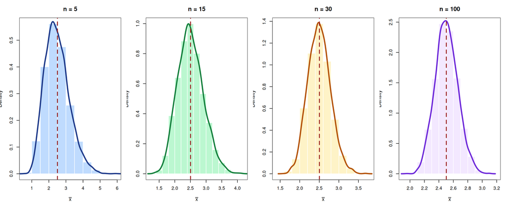

## Ejemplo: distribución muestral de la media

Peso de productos, Antioquia

El peso de productos Hass tiene $\mu = 280$ g y $\sigma = 35$ g. Se selecciona una muestra de $n = 49$ frutos. Calcule: (1) la distribución de $\bar{X}$, (2) $P(\bar{X} > 290)$.

Solución

Por el TLC: $\bar{X} \approx N\!\left(280,\; \dfrac{35^2}{49}\right) = N(280,\, 5^2)$

$$P(\bar{X} > 290) = P\!\left(Z > \frac{290-280}{5}\right) = P(Z > 2) \approx 0.0228$$

```r
1 - pnorm(290, mean = 280, sd = 35/sqrt(49))
```

```
[1] 0.02275013
```

## Ejemplo: distribución muestral de la proporción

Prevalencia de incumplimiento comercial, Huila

El 30% de los empresas en una región presenta incumplimiento ($p = 0.30$). Se seleccionan $n = 100$ empresas. Calcule $P(\hat{p} > 0.35)$.

Solución

$\text{SE}(\hat{p}) = \sqrt{0.30 \times 0.70 / 100} = \sqrt{0.0021} \approx 0.0458$

$$P(\hat{p} > 0.35) = P\!\left(Z > \frac{0.35 - 0.30}{0.0458}\right) = P(Z > 1.09) \approx 0.138$$

```r
p <- 0.30; n <- 100
se <- sqrt(p*(1-p)/n)
1 - pnorm(0.35, mean = p, sd = se)
```

```
[1] 0.1376168
```

Tamaño de Muestra

El tamaño de muestra determina la precisión de la estimación. A mayor $n$, menor error, pero también mayor costo: hay que encontrar el equilibrio.

## ¿Por qué importa el tamaño de muestra?

- Una muestra **demasiado pequeña** produce estimaciones imprecisas con errores grandes: no sirve para tomar decisiones.
- Una muestra **demasiado grande** desperdicia recursos sin ganancia proporcional en precisión (el SE cae como $1/\sqrt{n}$).
- El tamaño óptimo equilibra la **precisión deseada** (margen de error $e$), el **nivel de confianza** ($1-\alpha$) y la **variabilidad** de la variable.
- Se calcula **antes** de recolectar datos, a partir de un valor piloto de $\sigma$ o $p$.

## Margen de error e intervalo de confianza

Margen de error

El **margen de error** $e$ es la máxima diferencia tolerable entre el estimador y el parámetro, con probabilidad $1-\alpha$:
$$P(|\bar{X} - \mu| \leq e) = 1-\alpha \qquad \Longrightarrow \qquad e = z_{\alpha/2}\,\frac{\sigma}{\sqrt{n}}$$
donde $z_{\alpha/2}$ es el cuantil de la Normal estándar (ej. $z_{0.025} = 1.96$ para $95\%$).

Niveles de confianza usuales

| Confianza | $\alpha$ | $z_{\alpha/2}$ |
| --- | --- | --- |
| 90% | 0.10 | 1.645 |
| 95% | 0.05 | 1.960 |
| 99% | 0.01 | 2.576 |

Mayor confianza $\Rightarrow$ mayor $z_{\alpha/2}$ $\Rightarrow$ mayor $n$ requerido para el mismo margen $e$.

## Tamaño de muestra para estimar la media

Fórmula

Despejando $n$ de $e = z_{\alpha/2}\,\sigma/\sqrt{n}$:

$$\boxed{n = \left\lceil \frac{z_{\alpha/2}^2\,\sigma^2}{e^2} \right\rceil}$$

$\sigma$ se obtiene de estudios previos, literatura o una muestra piloto ($s$). Si se usa $s$, reemplazar $z$ por $t_{n_0-1,\,\alpha/2}$ (iterativo).

Ejemplo: peso de productoB, Nariño

Se quiere estimar el peso promedio de vainas con un error máximo de $e = 2$ g, confianza del 95%, y se sabe que $\sigma \approx 8$ g.

$$n = \left\lceil \frac{1.96^2 \times 64}{4} \right\rceil = \left\lceil \frac{245.86}{4} \right\rceil = \lceil 61.5 \rceil = 62$$

```r
ceiling((1.96^2 * 8^2) / 2^2)
```

```
[1] 62
```

## Tamaño de muestra para estimar una proporción

Fórmula

Del margen de error $e = z_{\alpha/2}\sqrt{p(1-p)/n}$:

$$\boxed{n = \left\lceil \frac{z_{\alpha/2}^2\,p(1-p)}{e^2} \right\rceil}$$

Si se desconoce $p$, se usa $p = 0.5$ (caso más conservador, maximiza $n$).

Ejemplo: mastitis bovina, Antioquia

Se estima la prevalencia de mastitis. Se quiere $e = 0.04$, confianza 95%. Estudio previo: $p \approx 0.25$.

$$n = \left\lceil \frac{1.96^2 \times 0.25 \times 0.75}{0.04^2} \right\rceil = \left\lceil \frac{0.7203}{0.0016} \right\rceil = 451$$

```r
ceiling((1.96^2 * 0.25 * 0.75) / 0.04^2)
```

```
[1] 451
```

## Factor de corrección para poblaciones finitas

Corrección por población finita

Cuando la muestra es una fracción apreciable de la población ($n/N > 0.05$), el verdadero error estándar es:
$$\text{SE}(\bar{X}) = \frac{\sigma}{\sqrt{n}}\sqrt{\frac{N-n}{N-1}} \qquad \text{(factor de corrección: } \sqrt{(N-n)/(N-1)}\text{)}$$
El tamaño ajustado es:
$$n^* = \frac{n_0}{1 + (n_0 - 1)/N}$$
donde $n_0$ es el tamaño calculado sin corrección.

Ejemplo en R

```r
n0 <- 62; N <- 300
n_ajustado <- ceiling(n0 / (1 + (n0 - 1) / N))
cat("Sin corrección:", n0, "| Con corrección:", n_ajustado, "\n")
```

```
Sin corrección: 62 | Con corrección: 52
```

## $n$ para distintos márgenes y confianzas

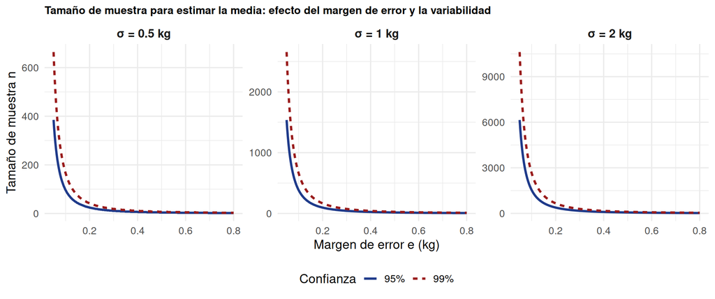

## Errores comunes en muestreo y tamaño de muestra

Advertencia: errores frecuentes

Verifique las condiciones antes de aplicar las fórmulas de tamaño de muestra.

- **Confundir error muestral con error de medición:** el tamaño de muestra controla el error por azar, no los errores sistemáticos de instrumento o protocolo.
- **Usar $p = 0.5$ siempre:** es conservador pero sobreestima $n$ cuando hay información previa confiable de $p$.
- **Olvidar el factor de corrección:** cuando $n/N > 5\%$, ignorarlo sobreestima el error estándar real.
- **Usar MAS cuando el diseño es estratificado o en conglomerados:** las fórmulas de SE difieren; ignorarlo puede producir inferencias incorrectas.

Introducción: Estimadores e Intervalos de Confianza

Preparando el terreno para la próxima clase

No veremos fórmulas todavía, sólo construiremos la intuición.

## ¿Por qué necesitamos estimadores?

El problema de fondo

Casi nunca podemos observar **toda** la población. Medir el mercado de cada sucursal del departamento, pesar cada fruto del empresa o revisar cada empresa de la empresa es **imposible en la práctica**.

La solución: el estimador

Usamos una **muestra** para aproximar las características de la población. El valor calculado a partir de la muestra que “apunta” al parámetro desconocido se llama **estimador**.

“La muestra nos permite aproximarnos a la población.”

Humedad promedio del mercado

Se miden 40 puntos de un lote de 5 000. La media de esos 40 puntos *estima* la humedad real del lote.

Producción promedio por sucursal

Se venden 30 sucursales de prueba. Su rentabilidad promedio *estima* la producción del empresa completo.

Proporción de empresas enfermas

Se revisan 80 empresas al azar. La fracción enferma en esa muestra *estima* la prevalencia real en la empresa.

## Diferentes muestras, resultados diferentes

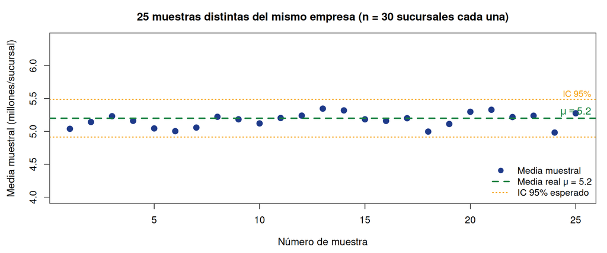

## ¿Obtendríamos el mismo resultado con otra muestra?

Cada muestra es única

Dos economistas que muestrean el mismo empresa obtendrán **medias distintas** aunque ambos sigan el mismo protocolo.

Hay variabilidad muestral

Esa diferencia no es un error: es la **variabilidad natural** del muestreo. La vimos en el gráfico anterior, es predecible y medible.

Necesitamos cuantificarla

Reportar solo $\bar{x} = 5.2$ sin más información **oculta** cuánta incertidumbre hay en esa estimación.

La respuesta estadística: en lugar de un punto, reportar un **rango plausible**.

## De un valor puntual a un rango plausible

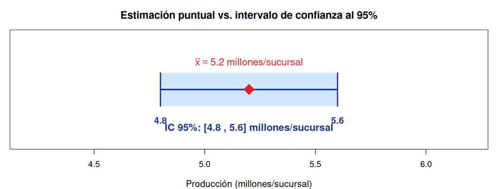

El **estimador puntual** ($\bar{x} = 5.2$) es nuestra mejor aproximación al valor real. Pero solo reportar ese número ignora la incertidumbre del muestreo.

El intervalo de confianza dice:

“Con los datos de esta muestra, la producción real del empresa está **plausiblemente** entre 4.8 y 5.6 millones/sucursal.” No es una garantía, es una declaración de incertidumbre cuantificada.

## El intervalo en tres ejemplos económicos

Humedad del mercado

Muestra de 40 puntos:

$\bar{x} = 38.4\%$

IC 95%: [36.1%, 40.7%]

El lote tiene entre 36 y 41% de humedad con 95% de confianza.

Rentabilidad de servicios

30 sucursales muestreadas:

$\bar{x} = 5.2$ millones/sucursal

IC 95%: [4.8, 5.6] millones/sucursal

La producción real está plausiblemente en ese rango.

Empresas enfermas

80 empresas revisadas:

$\hat{p} = 18\%$

IC 95%: [10%, 26%]

La prevalencia real en la empresa está en ese intervalo.

El intervalo más **ancho** refleja más incertidumbre; el más **estrecho** refleja mayor precisión. Ambos son válidos, lo que cambia es cuánto sabemos.

## Preguntas que guiarán la próxima clase

¿Cómo se construyen los intervalos?

Veremos la fórmula exacta y de dónde viene el factor $z_{\alpha/2}$.

¿Qué significa realmente “95%”?

No es que el parámetro esté 95% del tiempo en el intervalo, la interpretación correcta es más sutil.

¿Cómo influye el tamaño de muestra?

Mayor $n$ → intervalo más estrecho → más precisión. Veremos el trade-off exacto.

¿Qué es el error estándar?

El SE mide cuánto varía el estimador entre muestras. Es la clave de toda la construcción del intervalo.

¿Por qué algunos diseños son más precisos?

El diseño muestral (MAS vs estratificado) afecta directamente el SE y el ancho del intervalo.

El hilo conductor

Muestreo → distribución muestral → SE → intervalo de confianza. Todo conectado.

## Taller en clase

## Taller 1: tipos de muestreo

Problema

En un municipio del Meta hay 600 empresas ganaderas. Se quiere estimar la producción promedio de leche. Las empresas se clasifican como pequeñas (300), medianas (200) y grandes (100). Para cada diseño indicado, calcule el número de empresas a muestrear por estrato o sector, con $n = 60$ total:

1. MAS de 60 empresas.
2. Muestreo estratificado proporcional.
3. Muestreo sistemático con $k = 10$.

## Taller 2: tamaño de muestra

Problema

Un analista económico desea estimar la proporción de empresas de productos en Córdoba afectados por pudrición de producto. Estudios previos indican $p \approx 0.18$. Calcule el tamaño de muestra necesario para:

1. $e = 0.05$, confianza 95%.
2. $e = 0.03$, confianza 99%.
3. Repita el caso (1) asumiendo que se desconoce $p$.

## Resumen de la clase 12

Tipos de muestreo

- **MAS:** igual probabilidad para todas las muestras.
- **Sistemático:** intervalo fijo $k$ con arranque aleatorio.
- **Estratificado:** MAS dentro de grupos homogéneos.
- **Conglomerados:** grupos elegidos al azar, censados.

Distribuciones muestrales

- $E(\bar{X}) = \mu$, $\text{SE} = \sigma/\sqrt{n}$.
- $E(\hat{p}) = p$, $\text{SE} = \sqrt{p(1-p)/n}$.
- Por TLC: ambos $\approx$ Normal para $n$ grande.
- Cuadruplicar $n$ reduce el SE a la mitad.

**Próxima clase:** Estimación puntual e intervalos de confianza para media y proporción.